# Regions with changes in FIRE frequency - Genome wide analysis

Crystal Shan

2026-10-08

```r
library(ggplot2)
library(dplyr)
library(tidyr)
library(readr)
library(stringr)
library(ggpubr)
library(ggrepel)
library(tidyverse)
library(DT)
```

# FIRE frequency

Each region is a union FIRE peak across all timepoints. `n_reads` counts reads whose aligned span fully covers the region; `n_fire` counts those reads with a called FIRE element covering at least 50% of the region.

```r
input_dir <- "/project/spott/cshan/fiber-seq/macrophage_project/fire_frequency"

fire_freq <- read.csv(file.path(input_dir, "fire_frequency_long.tsv.gz"), sep = "\t")
head(fire_freq)
```

```
##   chrom start   end        region_id timepoint n_reads n_fire     freq
## 1  chr1 11261 11486 chr1:11261-11486     LPS_0       9      1 0.111111
## 2  chr1 21178 21359 chr1:21178-21359     LPS_0      71      8 0.112676
## 3  chr1 28997 29166 chr1:28997-29166     LPS_0      26      8 0.307692
## 4  chr1 29283 29478 chr1:29283-29478     LPS_0      24     19 0.791667
## 5  chr1 29964 30121 chr1:29964-30121     LPS_0      23      6 0.260870
## 6  chr1 38601 38804 chr1:38601-38804     LPS_0      19      4 0.210526
```

```r
# group by region_id and timepoint, and calculate the mean frequency
fire_freq_summary <- fire_freq %>%
  group_by(region_id, timepoint) %>%
  summarise(mean_freq = mean(freq, na.rm = TRUE)) %>%
  ungroup()
```

[output not shown]

```r
# rank region by mean frequency for each timepoint
fire_freq_summary <- fire_freq_summary %>%
  group_by(timepoint) %>%
  mutate(rank = rank(-mean_freq, ties.method = "first")) %>%
  ungroup()

head(fire_freq_summary)
```

```
## # A tibble: 6 × 4
##   region_id                 timepoint mean_freq   rank
##   <chr>                     <chr>         <dbl>  <int>
## 1 chr10:100006359-100006588 LPS_0         0.333  78234
## 2 chr10:100006359-100006588 LPS_10        0.75   16354
## 3 chr10:100006359-100006588 LPS_15        0.385  64567
## 4 chr10:100006359-100006588 LPS_5         0.389  64518
## 5 chr10:100006712-100006884 LPS_0         0.290  91144
## 6 chr10:100006712-100006884 LPS_10        0.111 136829
```

# cumulative distribution of FIRE frequency for each timepoint

for a given frequency x, what fraction of FIRE-universe regions have frequency ≤ x?

Left-shifted curve = more regions accumulate at lower x values → overall lower FIRE frequencies

```r
source("/project/spott/cshan/fiber-seq/code/parsing_functions/plotting_functions.r", local = TRUE)

fire_freq_cdf <- fire_freq_summary %>%
  filter(!is.na(mean_freq)) %>%
  group_by(timepoint) %>%
  arrange(mean_freq, .by_group = TRUE) %>%
  mutate(
    cdf = row_number() / n()
  ) %>%
  ungroup()

head(fire_freq_cdf)
```

```
## # A tibble: 6 × 5
##   region_id                 timepoint mean_freq   rank        cdf
##   <chr>                     <chr>         <dbl>  <int>      <dbl>
## 1 chr10:102435415-102435526 LPS_0             0 142552 0.00000699
## 2 chr10:102454756-102454938 LPS_0             0 142553 0.0000140
## 3 chr10:102801690-102801878 LPS_0             0 142554 0.0000210
## 4 chr10:103192136-103192330 LPS_0             0 142555 0.0000280
## 5 chr10:103192922-103193089 LPS_0             0 142556 0.0000350
## 6 chr10:103277524-103277657 LPS_0             0 142557 0.0000419
```

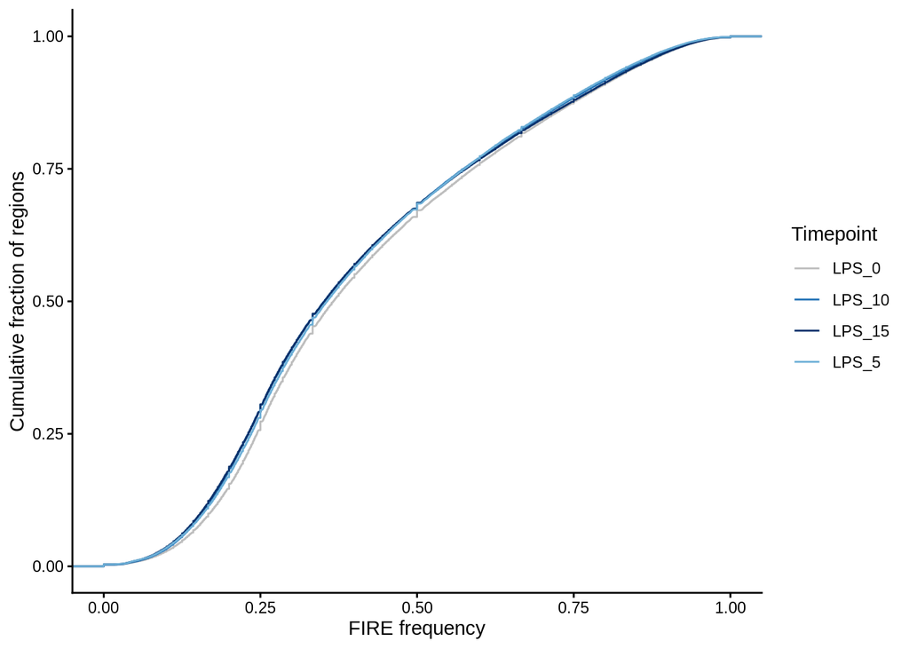

```r
p_freq_cdf <- ggplot(fire_freq_cdf, aes(x = mean_freq, color = timepoint)) +
  stat_ecdf(na.rm = TRUE) +
  scale_color_manual(values = timepoint_palette(fire_freq_cdf$timepoint)) +
  labs(
    x = "FIRE frequency",
    y = "Cumulative fraction of regions",
    color = "Timepoint"
  ) +
  theme_classic()
p_freq_cdf
```

# Pairwise differential FIRE frequency: top 100 regions

Top 100 regions per comparison, ranked by Fisher exact p-value among coverage-passing regions (6 comparisons x 100 rows).

```r
pairwise <- read_tsv(file.path(input_dir, "pairwise_fisher.tsv.gz"),
                     show_col_types = FALSE)

comparison_levels <- c("LPS_0_vs_LPS_5", "LPS_0_vs_LPS_10", "LPS_0_vs_LPS_15",
                       "LPS_5_vs_LPS_10", "LPS_5_vs_LPS_15", "LPS_10_vs_LPS_15")
pairwise <- pairwise %>%
  mutate(comparison = factor(comparison, levels = comparison_levels))

# only coverage-passing regions were ranked in 04_pairwise_differential.R
passing <- pairwise %>% filter(pass_coverage)

# top 100 per comparison by raw p
top100 <- passing %>%
  group_by(comparison) %>%
  arrange(p_value, .by_group = TRUE) %>%
  slice_head(n = 100) %>%
  ungroup() %>%
  mutate(direction = ifelse(delta_freq > 0, "gain", "loss"))

# gain = higher FIRE frequency at the later timepoint
table(top100$comparison, top100$direction)
```

```
##
##                    gain loss
##   LPS_0_vs_LPS_5     38   62
##   LPS_0_vs_LPS_10    27   73
##   LPS_0_vs_LPS_15    55   45
##   LPS_5_vs_LPS_10    55   45
##   LPS_5_vs_LPS_15    62   38
##   LPS_10_vs_LPS_15   66   34
```

# Regions tested vs significant

Tested = coverage-passing regions in that comparison; significant = unadjusted Fisher p < 0.05. “any comparison” is the union across the 6 comparisons, i.e. the definition used in the cCRE section below.

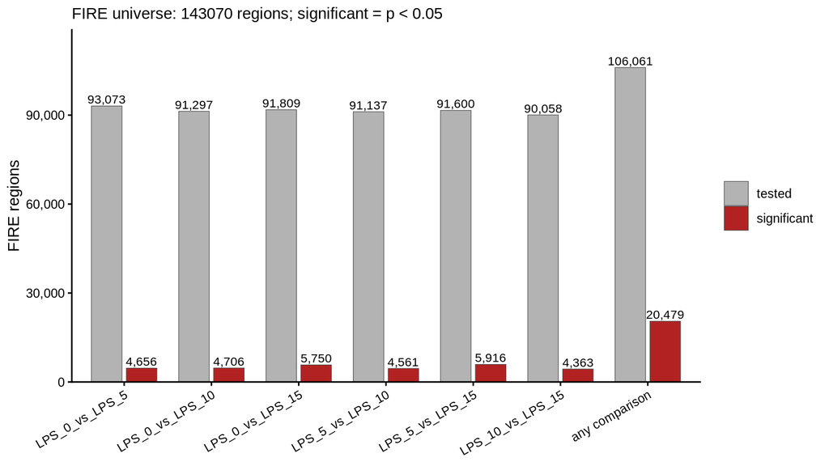

```r
p_sig <- 0.05

counts_by_comparison <- passing %>%
  group_by(comparison) %>%
  summarise(tested      = n(),
            significant = sum(p_value < p_sig),
            .groups = "drop") %>%
  mutate(group = as.character(comparison))

counts_union <- tibble(
  group       = "any comparison",
  tested      = n_distinct(passing$region_id),
  significant = n_distinct(passing$region_id[passing$p_value < p_sig]))

region_counts <- bind_rows(counts_by_comparison %>% select(group, tested, significant),
                           counts_union) %>%
  mutate(group = factor(group, levels = c(comparison_levels, "any comparison")))

region_counts_long <- region_counts %>%
  pivot_longer(c(tested, significant), names_to = "category", values_to = "n") %>%
  mutate(category = factor(category, levels = c("tested", "significant")))

p_region_counts <- ggplot(region_counts_long, aes(x = group, y = n, fill = category)) +
  geom_col(position = position_dodge(width = 0.8), width = 0.7,
           color = "grey30", linewidth = 0.2) +
  geom_text(aes(label = scales::comma(n)), position = position_dodge(width = 0.8),
            vjust = -0.3, size = 3) +
  scale_fill_manual(values = c(tested = "grey70", significant = "firebrick")) +
  scale_y_continuous(labels = scales::comma,
                     expand = expansion(mult = c(0, 0.12))) +
  labs(x = NULL, y = "FIRE regions", fill = NULL,
       subtitle = paste0("FIRE universe: ", n_distinct(pairwise$region_id),
                         " regions; significant = p < ", p_sig)) +
  theme_classic() +
  theme(axis.text.x = element_text(angle = 30, hjust = 1))
p_region_counts
```

```r
region_counts %>% mutate(frac_signif = round(significant / tested, 3))
```

```
## # A tibble: 7 × 4
##   group            tested significant frac_signif
##   <fct>             <int>       <int>       <dbl>
## 1 LPS_0_vs_LPS_5    93073        4656       0.05
## 2 LPS_0_vs_LPS_10   91297        4706       0.052
## 3 LPS_0_vs_LPS_15   91809        5750       0.063
## 4 LPS_5_vs_LPS_10   91137        4561       0.05
## 5 LPS_5_vs_LPS_15   91600        5916       0.065
## 6 LPS_10_vs_LPS_15  90058        4363       0.048
## 7 any comparison   106061       20479       0.193
```

# P-value distribution per comparison

Histogram of the unadjusted Fisher p-values

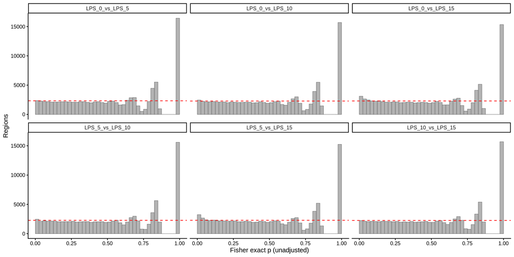

```r
expected_bin <- passing %>%
  count(comparison) %>%
  mutate(expected = n * 0.025)

p_pval_hist <- ggplot(passing, aes(x = p_value)) +
  geom_histogram(binwidth = 0.025, boundary = 0,
                 fill = "grey70", color = "grey30", linewidth = 0.2) +
  geom_hline(data = expected_bin, aes(yintercept = expected),
             linetype = "dashed", color = "red") +
  facet_wrap(~ comparison, nrow = 2) +
  labs(x = "Fisher exact p (unadjusted)", y = "Regions") +
  theme_classic()
p_pval_hist
```

# Volcano: effect size vs significance

Effect size = delta_freq (later - earlier FIRE frequency); significance = -log10 of the unadjusted Fisher p. Coverage-passing regions only. Points are coloured by direction among the regions with p < 0.05.

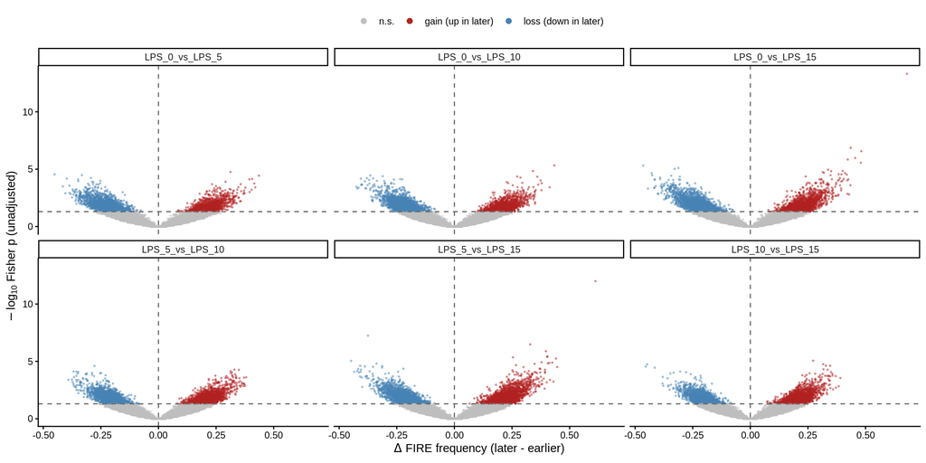

```r
volcano <- passing %>%
  mutate(neglog10_p = -log10(p_value),
         status = case_when(p_value >= p_sig  ~ "n.s.",
                            delta_freq > 0    ~ "gain (up in later)",
                            TRUE              ~ "loss (down in later)"),
         status = factor(status, levels = c("n.s.", "gain (up in later)",
                                            "loss (down in later)")))

status_cols <- c("n.s." = "grey75",
                 "gain (up in later)" = "firebrick",
                 "loss (down in later)" = "steelblue")

p_volcano <- ggplot(volcano, aes(x = delta_freq, y = neglog10_p, color = status)) +
  geom_point(size = 0.4, alpha = 0.4) +
  geom_hline(yintercept = -log10(p_sig), linetype = "dashed", color = "grey40") +
  geom_vline(xintercept = 0, linetype = "dashed", color = "grey40") +
  facet_wrap(~ comparison, nrow = 2) +
  scale_color_manual(values = status_cols) +
  guides(color = guide_legend(override.aes = list(size = 2, alpha = 1))) +
  labs(x = expression(Delta ~ "FIRE frequency (later - earlier)"),
       y = expression(-log[10] ~ "Fisher p (unadjusted)"), color = NULL) +
  theme_classic() +
  theme(legend.position = "top")
p_volcano
```

## LPS_0 vs LPS_15: regions gained and lost at 15 min

Same volcano restricted to the 0 vs 15 min comparison. Labelled points are the top 10 in each direction: p < 0.05 and the largest |delta_freq|, i.e. the regions with the highest FIRE frequency at 15 min relative to 0 (gains) and the lowest at 15 min relative to 0 (losses).

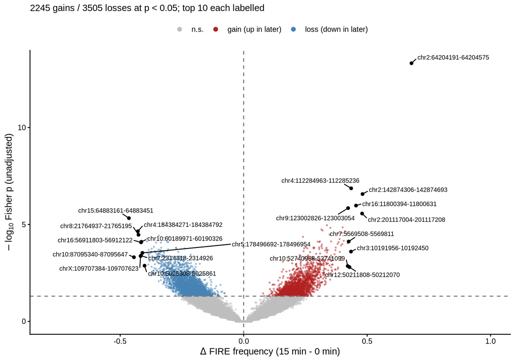

```r
n_label <- 10

v15 <- volcano %>% filter(comparison == "LPS_0_vs_LPS_15")

top_gain_15 <- v15 %>%
  filter(p_value < p_sig, delta_freq > 0) %>%
  arrange(desc(delta_freq), p_value) %>%
  mutate(rank = row_number(), direction = "gain")

top_loss_15 <- v15 %>%
  filter(p_value < p_sig, delta_freq < 0) %>%
  arrange(delta_freq, p_value) %>%
  mutate(rank = row_number(), direction = "loss")

labelled_15 <- bind_rows(head(top_gain_15, n_label), head(top_loss_15, n_label))

p_volcano_15 <- ggplot(v15, aes(x = delta_freq, y = neglog10_p, color = status)) +
  geom_point(size = 0.5, alpha = 0.4) +
  geom_hline(yintercept = -log10(p_sig), linetype = "dashed", color = "grey40") +
  geom_vline(xintercept = 0, linetype = "dashed", color = "grey40") +
  geom_point(data = labelled_15, color = "black", size = 1.4) +
  geom_text_repel(data = labelled_15, aes(label = region_id),
                  color = "black", size = 2.6, min.segment.length = 0,
                  max.overlaps = Inf, box.padding = 0.4) +
  scale_color_manual(values = status_cols) +

  scale_x_continuous(expand = expansion(mult = c(0.35, 0.35))) +
  guides(color = guide_legend(override.aes = list(size = 2, alpha = 1))) +
  labs(x = expression(Delta ~ "FIRE frequency (15 min - 0 min)"),
       y = expression(-log[10] ~ "Fisher p (unadjusted)"), color = NULL,
       subtitle = paste0(nrow(top_gain_15), " gains / ", nrow(top_loss_15),
                         " losses at p < ", p_sig,
                         "; top ", n_label, " each labelled")) +
  theme_classic() +
  theme(legend.position = "top")
p_volcano_15
```

```r
top_15 <- bind_rows(top_gain_15, top_loss_15)
write_tsv(top_15, file.path(input_dir, "top_changed_LPS_0_vs_LPS_15.tsv"))

# shared column layout for the two direction tables
format_top15 <- function(d) {
  d %>%
    transmute(rank, region_id,
              n_reads_0 = n_reads_A, freq_0 = round(freq_A, 3),
              n_reads_15 = n_reads_B, freq_15 = round(freq_B, 3),
              delta_freq = round(delta_freq, 3), log2_or = round(log2_or, 2),
              p_value = signif(p_value, 3))
}
```

Gains: higher FIRE frequency at 15 min than at 0, ranked by delta_freq.

```r
datatable(format_top15(top_gain_15), filter = "top", rownames = FALSE,
          caption = paste0("LPS_0 vs LPS_15 gains (p < ", p_sig, "): ",
                           nrow(top_gain_15), " regions"),
          options = list(pageLength = 10))
```

| rank | region_id | n_reads_0 | freq_0 | n_reads_15 | freq_15 | delta_freq | log2_or | p_value |
| --- | --- | --- | --- | --- | --- | --- | --- | --- |
| 1 | chr2:64204191-64204575 | 48 | 0.042 | 61 | 0.721 | 0.68 | 5.56 | 4.81e-14 |
| 2 | chr2:142874306-142874693 | 46 | 0.109 | 61 | 0.59 | 0.481 | 3.43 | 2.69e-07 |
| 3 | chr2:201117004-201117208 | 38 | 0.105 | 53 | 0.585 | 0.48 | 3.42 | 2.72e-06 |
| 4 | chr16:11800394-11800631 | 63 | 0.286 | 54 | 0.741 | 0.455 | 2.78 | 1.06e-06 |
| 5 | chr4:112284963-112285236 | 49 | 0.041 | 63 | 0.476 | 0.435 | 4.11 | 1.37e-07 |
| 6 | chr3:10191956-10192450 | 36 | 0.389 | 34 | 0.824 | 0.435 | 2.77 | 0.00025 |
| 7 | chr12:50211808-50212070 | 28 | 0.321 | 32 | 0.75 | 0.429 | 2.56 | 0.00159 |
| 8 | chr7:5569508-5569811 | 41 | 0.512 | 32 | 0.938 | 0.425 | 3.54 | 7.57e-05 |
| 9 | chr9:123002826-123003054 | 53 | 0.472 | 57 | 0.895 | 0.423 | 3.15 | 1.43e-06 |
| 10 | chr10:52740938-52741099 | 29 | 0.172 | 32 | 0.594 | 0.421 | 2.69 | 0.00139 |

[output cut: 2235 more lines]

Losses: lower FIRE frequency at 15 min than at 0, ranked by the most negative delta_freq.

```r
datatable(format_top15(top_loss_15), filter = "top", rownames = FALSE,
          caption = paste0("LPS_0 vs LPS_15 losses (p < ", p_sig, "): ",
                           nrow(top_loss_15), " regions"),
          options = list(pageLength = 10))
```

| rank | region_id | n_reads_0 | freq_0 | n_reads_15 | freq_15 | delta_freq | log2_or | p_value |
| --- | --- | --- | --- | --- | --- | --- | --- | --- |
| 1 | chr15:64883161-64883451 | 44 | 0.614 | 47 | 0.149 | -0.465 | -3.09 | 4.72e-06 |
| 2 | chr10:87095340-87095647 | 29 | 0.759 | 35 | 0.314 | -0.444 | -2.68 | 0.000489 |
| 3 | chr4:184384271-184384792 | 53 | 0.755 | 49 | 0.327 | -0.428 | -2.61 | 2.23e-05 |
| 4 | chr8:21764937-21765195 | 48 | 0.646 | 50 | 0.22 | -0.426 | -2.63 | 3.41e-05 |
| 5 | chrX:109707384-109707623 | 31 | 0.903 | 35 | 0.486 | -0.418 | -3.11 | 0.000423 |
| 6 | chr16:56911803-56912122 | 30 | 0.933 | 56 | 0.518 | -0.415 | -3.41 | 8.35e-05 |
| 7 | chr7:2314318-2314926 | 38 | 0.632 | 37 | 0.216 | -0.415 | -2.55 | 0.000408 |
| 8 | chr10:60189971-60190326 | 40 | 0.475 | 33 | 0.061 | -0.414 | -3.51 | 7.83e-05 |
| 9 | chr5:178496692-178496954 | 30 | 0.8 | 59 | 0.39 | -0.41 | -2.55 | 0.000292 |
| 10 | chr10:5025308-5025861 | 31 | 0.548 | 34 | 0.147 | -0.401 | -2.69 | 0.00134 |

[output cut: 3495 more lines]

# QQ plot: observed vs null p-values

Do Fisher’s p values from FIRE frequency comparisons contain more small p values than expected if there were no real differences between timepoints?

1. For each pairwise comparison, all coverage passing regions are ranked from smallest to largest p values, the observed fisher p-vlaue for each region is converted to -log10(p), and is plotted against the -log10(p) expected at the same rank if all p values follow a unifomr (0,1) null distribution
2. Points above the diagonal means there are more very small p values than expected

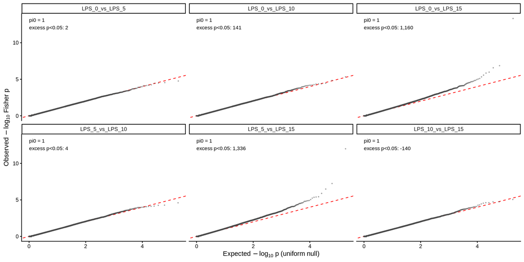

```r
qq <- passing %>%
  group_by(comparison) %>%
  arrange(p_value, .by_group = TRUE) %>%
  # convert to -log(10) based p value
  mutate(observed = -log10(p_value),
         # expected p value at the same rank if all regions are null
         expected = -log10((row_number() - 0.5) / n())) %>%
  ungroup()

pi0_tab <- passing %>%
  group_by(comparison) %>%
  # count how many regions are tested in each pairwise comparison
  summarise(tested = n(),
            # fraction of tests behave like null hypothesis
            pi0    = min(1, mean(p_value > 0.5) / 0.5),
            # number of regions with fisher p value < 0.05
            signif = sum(p_value < p_sig),
            .groups = "drop") %>%
  # estimated number of sig regions from the null hypothesis alone
  mutate(expected_null_signif = round(pi0 * tested * p_sig),
         excess               = signif - expected_null_signif)

# keeps the 5000 smallest p values
qq_thin <- qq %>%
  group_by(comparison) %>%
  filter(row_number() <= 5000 | row_number() %% 20 == 0) %>%
  ungroup()

# summary table
pi0_lab <- pi0_tab %>%
  mutate(label = paste0("pi0 = ", round(pi0, 2),
                        "\nexcess p<", p_sig, ": ", scales::comma(excess)))

# qq plot
  # x = expected -log10(p)
  # y = observed -log10(fisher p)
p_qq <- ggplot(qq_thin, aes(x = expected, y = observed)) +
  geom_abline(slope = 1, intercept = 0, color = "red", linetype = "dashed") +
  geom_point(size = 0.4, alpha = 0.4, color = "grey30") +
  geom_text(data = pi0_lab, aes(x = 0, y = max(qq$observed), label = label),
            hjust = 0, vjust = 1, size = 3, inherit.aes = FALSE) +
  facet_wrap(~ comparison, nrow = 2) +
  labs(x = expression("Expected" ~ -log[10] ~ "p (uniform null)"),
       y = expression("Observed" ~ -log[10] ~ "Fisher p")) +
  theme_classic()
p_qq
```

```r
pi0_tab %>% mutate(pi0 = round(pi0, 3))
```

```
## # A tibble: 6 × 6
##   comparison       tested   pi0 signif expected_null_signif excess
##   <fct>             <int> <dbl>  <int>                <dbl>  <dbl>
## 1 LPS_0_vs_LPS_5    93073     1   4656                 4654      2
## 2 LPS_0_vs_LPS_10   91297     1   4706                 4565    141
## 3 LPS_0_vs_LPS_15   91809     1   5750                 4590   1160
## 4 LPS_5_vs_LPS_10   91137     1   4561                 4557      4
## 5 LPS_5_vs_LPS_15   91600     1   5916                 4580   1336
## 6 LPS_10_vs_LPS_15  90058     1   4363                 4503   -140
```

# Significant regions vs ENCODE cCREs

Significant = unadjusted Fisher p < 0.05 in at least one of the 6 pairwise comparisons

`ccre_class` / `ccre_id` report that best cCRE.

```r
suppressPackageStartupMessages(library(GenomicRanges))

ccre_file <- "/project/spott/cshan/annotations/GRCh38-cCREs.bed"
p_sig <- 0.05

signif_rows <- passing %>% filter(p_value < p_sig)

# region level: keep the samllest p comparison for ranking
signif_regions <- signif_rows %>%
  group_by(region_id, chrom, start, end) %>%
  summarise(n_signif_comparisons = n(),
            min_p           = min(p_value),
            best_comparison = comparison[which.min(p_value)],
            delta_freq_best = delta_freq[which.min(p_value)],
            .groups = "drop")

ccre <- data.table::fread(ccre_file, header = FALSE,
                          col.names = c("chr", "start", "end",
                                        "ccre_dcc", "ccre_id", "ccre_class"))

reg.gr  <- GRanges(signif_regions$chrom,
                   IRanges(signif_regions$start + 1L, signif_regions$end))
ccre.gr <- GRanges(ccre$chr, IRanges(ccre$start + 1L, ccre$end))
hits <- findOverlaps(reg.gr, ccre.gr)
ov_frac <- width(pintersect(reg.gr[queryHits(hits)], ccre.gr[subjectHits(hits)])) /
  width(reg.gr)[queryHits(hits)]

# best cCRE per region (largest covered fraction)
best <- data.frame(ri = queryHits(hits), frac = ov_frac,
                   ccre_id = ccre$ccre_id[subjectHits(hits)],
                   ccre_class = ccre$ccre_class[subjectHits(hits)]) %>%
  group_by(ri) %>%
  slice_max(frac, n = 1, with_ties = FALSE) %>%
  ungroup()

signif_regions <- signif_regions %>%
  mutate(ccre_frac = 0, ccre_id = NA_character_, ccre_class = NA_character_)
signif_regions$ccre_frac[best$ri]  <- best$frac
signif_regions$ccre_id[best$ri]    <- best$ccre_id
signif_regions$ccre_class[best$ri] <- best$ccre_class

signif_ccre <- signif_regions %>% filter(ccre_frac >= 0.5)

tibble(n_signif_regions = nrow(signif_regions),
       any_ccre_overlap = sum(signif_regions$ccre_frac > 0),
       ccre_50          = nrow(signif_ccre),
       frac_ccre_50     = round(nrow(signif_ccre) / nrow(signif_regions), 3))
```

```
## # A tibble: 1 × 4
##   n_signif_regions any_ccre_overlap ccre_50 frac_ccre_50
##              <int>            <int>   <int>        <dbl>
## 1            20479            19850   18830        0.919
```

Nearest gencode v46 gene for the cCRE-supported regions (distance 0 = overlapping the gene body)

```r
gtf_file <- "/project/spott/cshan/annotations/gencode.v46.annotation.gtf.gz"
gtf <- data.table::fread(cmd = paste("zcat", gtf_file, "| awk -F'\\t' '$3==\"gene\"'"),
                         header = FALSE, sep = "\t")
genes.gr <- GRanges(gtf$V1, IRanges(gtf$V4, gtf$V5),
                    gene_name = sub('.*gene_name "([^"]+)".*', "\\1", gtf$V9),
                    gene_type = sub('.*gene_type "([^"]+)".*', "\\1", gtf$V9))

sc.gr <- GRanges(signif_ccre$chrom, IRanges(signif_ccre$start + 1L, signif_ccre$end))
d <- distanceToNearest(sc.gr, genes.gr)
signif_ccre$nearest_gene  <- NA_character_
signif_ccre$nearest_gene_type <- NA_character_
signif_ccre$gene_distance <- NA_integer_
signif_ccre$nearest_gene[queryHits(d)]      <- genes.gr$gene_name[subjectHits(d)]
signif_ccre$nearest_gene_type[queryHits(d)] <- genes.gr$gene_type[subjectHits(d)]
signif_ccre$gene_distance[queryHits(d)] <- mcols(d)$distance

write_tsv(signif_ccre %>% arrange(min_p),
          file.path(input_dir, "signif_ccre_regions.tsv"))
```

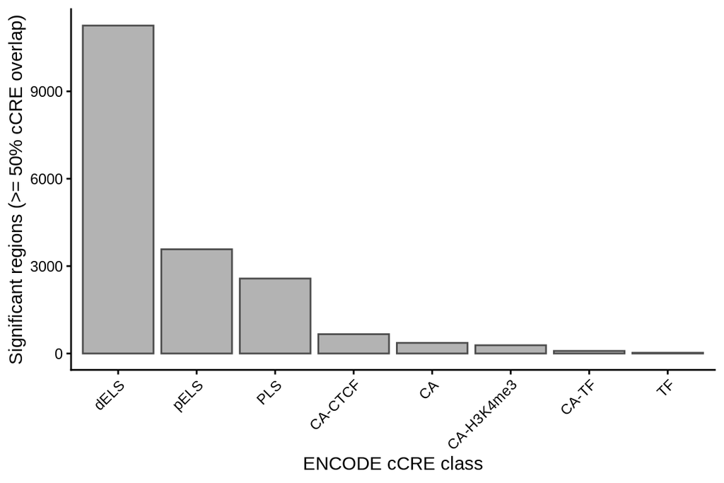

```r
p_ccre_class <- signif_ccre %>%
  count(ccre_class) %>%
  ggplot(aes(x = reorder(ccre_class, -n), y = n)) +
  geom_col(fill = "grey70", color = "grey30") +
  labs(x = "ENCODE cCRE class",
       y = "Significant regions (>= 50% cCRE overlap)") +
  theme_classic() +
  theme(axis.text.x = element_text(angle = 45, hjust = 1))
p_ccre_class
```

Top 100 cCRE-supported significant regions by best p (full table in `signif_ccre_regions.tsv`).

```r
signif_ccre %>%
  arrange(min_p) %>%
  head(100) %>%
  transmute(region_id, best_comparison, n_signif_comparisons,
            min_p = signif(min_p, 3),
            delta_freq_best = round(delta_freq_best, 3),
            ccre_id, ccre_class, ccre_frac = round(ccre_frac, 2),
            nearest_gene, gene_distance) %>%
  datatable(filter = "top", rownames = FALSE, options = list(pageLength = 20))
```

| region_id | best_comparison | n_signif_comparisons | min_p | delta_freq_best | ccre_id | ccre_class | ccre_frac | nearest_gene | gene_distance |
| --- | --- | --- | --- | --- | --- | --- | --- | --- | --- |
| chr2:64204191-64204575 | LPS_0_vs_LPS_15 | 5 | 4.81e-14 | 0.68 | EH38E3347830 | pELS | 0.91 | LINC00309 | 0 |
| chr11:128582973-128583191 | LPS_5_vs_LPS_15 | 1 | 5.73e-08 | -0.375 | EH38E2993686 | dELS | 1 | ETS1 | 0 |
| chr4:112284963-112285236 | LPS_0_vs_LPS_15 | 4 | 1.37e-07 | 0.435 | EH38E3600302 | pELS | 1 | TIFA | 0 |
| chr2:142874306-142874693 | LPS_0_vs_LPS_15 | 4 | 2.69e-07 | 0.481 | EH38E3375162 | dELS | 0.85 | KYNU | 2963 |
| chr2:55585837-55586002 | LPS_5_vs_LPS_15 | 3 | 3.3e-07 | 0.329 | EH38E1999514 | dELS | 1 | PPP4R3B | 0 |
| chr16:11800394-11800631 | LPS_0_vs_LPS_15 | 3 | 1.06e-06 | 0.455 | EH38E3168798 | dELS | 1 | ENSG00000277369 | 2119 |
| chr1:55215692-55215938 | LPS_5_vs_LPS_15 | 4 | 1.29e-06 | 0.397 | EH38E2813228 | pELS | 0.7 | USP24 | 314 |
| chr9:123002826-123003054 | LPS_0_vs_LPS_15 | 3 | 1.43e-06 | 0.423 | EH38E2724926 | dELS | 1 | RABGAP1 | 0 |
| chr2:201117004-201117208 | LPS_0_vs_LPS_15 | 4 | 2.72e-06 | 0.48 | EH38E2065830 | pELS | 1 | CFLAR | 0 |
| chr6:43224386-43224664 | LPS_5_vs_LPS_15 | 2 | 3.68e-06 | 0.404 | EH38E3708907 | pELS | 1 | CUL9 | 0 |

[output cut: 90 more lines]

# Read-level plots: top 10 cCRE-supported differential regions

```r
code_dir <- "/project/spott/cshan/fiber-seq/code/topic_model/read_region_extraction"
source(file.path(code_dir, "region_data_utils.R"))
source(file.path(code_dir, "region_plot_functions.R"))
```

```r
options(scipen = 999)

extract_script <- file.path(code_dir, "extract_region_result_macrophage.sh")
extract_root <- "/project/spott/cshan/fiber-seq/macrophage_project/fire_frequency/region_plots"
sample_names <- c("LPS_0", "LPS_5", "LPS_10", "LPS_15")
pad <- 1000

# Keep the existing protein-coding nearest-gene filter and rank by best p-value.
top10 <- signif_ccre %>%
  filter(nearest_gene_type == "protein_coding") %>%
  arrange(min_p) %>%
  head(10) %>%
  mutate(rank = row_number(),
         outname = paste(chrom, start, end, sep = "_"),
         window_start = as.integer(start - pad),
         window_end   = as.integer(end + pad))
```

Top 10 cCRE-supported differential regions selected for read-level plots

| rank | region_id | best_comparison | min_p | delta_freq_best | ccre_id | ccre_class | ccre_frac | nearest_gene | gene_distance |
| --- | --- | --- | --- | --- | --- | --- | --- | --- | --- |
| 1 | chr11:128582973-128583191 | LPS_5_vs_LPS_15 | 5.731e-08 | -0.375 | EH38E2993686 | dELS | 1.00 | ETS1 | 0 |
| 2 | chr4:112284963-112285236 | LPS_0_vs_LPS_15 | 1.366e-07 | 0.435 | EH38E3600302 | pELS | 1.00 | TIFA | 0 |
| 3 | chr2:142874306-142874693 | LPS_0_vs_LPS_15 | 2.695e-07 | 0.481 | EH38E3375162 | dELS | 0.85 | KYNU | 2963 |
| 4 | chr2:55585837-55586002 | LPS_5_vs_LPS_15 | 3.296e-07 | 0.329 | EH38E1999514 | dELS | 1.00 | PPP4R3B | 0 |
| 5 | chr1:55215692-55215938 | LPS_5_vs_LPS_15 | 1.292e-06 | 0.397 | EH38E2813228 | pELS | 0.70 | USP24 | 314 |
| 6 | chr9:123002826-123003054 | LPS_0_vs_LPS_15 | 1.428e-06 | 0.423 | EH38E2724926 | dELS | 1.00 | RABGAP1 | 0 |
| 7 | chr2:201117004-201117208 | LPS_0_vs_LPS_15 | 2.723e-06 | 0.480 | EH38E2065830 | pELS | 1.00 | CFLAR | 0 |
| 8 | chr6:43224386-43224664 | LPS_5_vs_LPS_15 | 3.681e-06 | 0.404 | EH38E3708907 | pELS | 1.00 | CUL9 | 0 |
| 9 | chr3:101827658-101828081 | LPS_5_vs_LPS_15 | 4.037e-06 | 0.402 | EH38E3528484 | PLS | 0.83 | NFKBIZ | 0 |
| 10 | chr15:64883161-64883451 | LPS_0_vs_LPS_15 | 4.723e-06 | -0.465 | EH38E1770299 | pELS | 1.00 | ENSG00000249240 | 0 |

```
## === chr11:128582973-128583191 (dELS, nearest gene: ETS1) ===
## Loading LPS_0 from /project/spott/cshan/fiber-seq/macrophage_project/fire_frequency/region_plots/chr11_128582973_128583191/LPS_0/parsed
## Loading LPS_5 from /project/spott/cshan/fiber-seq/macrophage_project/fire_frequency/region_plots/chr11_128582973_128583191/LPS_5/parsed
## Loading LPS_10 from /project/spott/cshan/fiber-seq/macrophage_project/fire_frequency/region_plots/chr11_128582973_128583191/LPS_10/parsed
## Loading LPS_15 from /project/spott/cshan/fiber-seq/macrophage_project/fire_frequency/region_plots/chr11_128582973_128583191/LPS_15/parsed
## 419 reads in the region across 4 samples
## 4474 TF footprints, 1398 of them inside a FIRE element
## 2744 nucleosome calls in 130-160 bp
## 419 reads in region result; 419 grouped; 0 dropped.
##
##          LPS_0 LPS_10 LPS_15 LPS_5
##   LPS_0     95      0      0     0
##   LPS_5      0      0      0    93
##   LPS_10     0    134      0     0
##   LPS_15     0      0     97     0
```

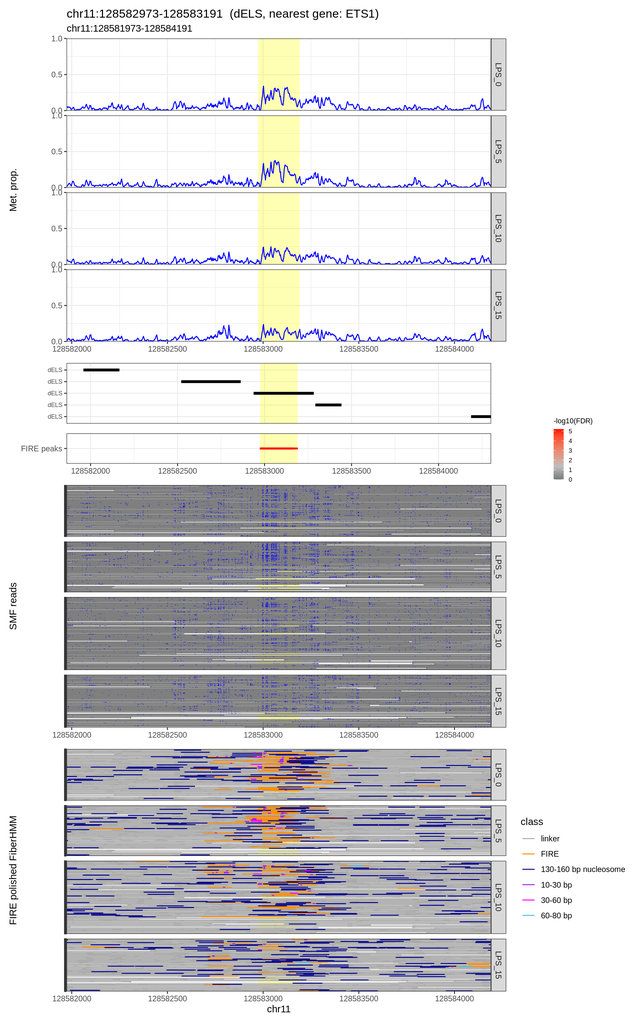

```
## === chr4:112284963-112285236 (pELS, nearest gene: TIFA) ===
## Loading LPS_0 from /project/spott/cshan/fiber-seq/macrophage_project/fire_frequency/region_plots/chr4_112284963_112285236/LPS_0/parsed
## Loading LPS_5 from /project/spott/cshan/fiber-seq/macrophage_project/fire_frequency/region_plots/chr4_112284963_112285236/LPS_5/parsed
## Loading LPS_10 from /project/spott/cshan/fiber-seq/macrophage_project/fire_frequency/region_plots/chr4_112284963_112285236/LPS_10/parsed
## Loading LPS_15 from /project/spott/cshan/fiber-seq/macrophage_project/fire_frequency/region_plots/chr4_112284963_112285236/LPS_15/parsed
## 259 reads in the region across 4 samples
## 3570 TF footprints, 1068 of them inside a FIRE element
## 2371 nucleosome calls in 130-160 bp
## 259 reads in region result; 259 grouped; 0 dropped.
##
##          LPS_0 LPS_10 LPS_15 LPS_5
##   LPS_0     63      0      0     0
##   LPS_5      0      0      0    59
##   LPS_10     0     65      0     0
##   LPS_15     0      0     72     0
```

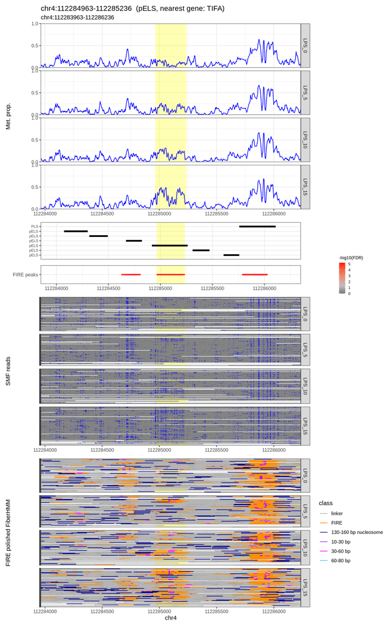

```
## === chr2:142874306-142874693 (dELS, nearest gene: KYNU) ===
## Loading LPS_0 from /project/spott/cshan/fiber-seq/macrophage_project/fire_frequency/region_plots/chr2_142874306_142874693/LPS_0/parsed
## Loading LPS_5 from /project/spott/cshan/fiber-seq/macrophage_project/fire_frequency/region_plots/chr2_142874306_142874693/LPS_5/parsed
## Loading LPS_10 from /project/spott/cshan/fiber-seq/macrophage_project/fire_frequency/region_plots/chr2_142874306_142874693/LPS_10/parsed
## Loading LPS_15 from /project/spott/cshan/fiber-seq/macrophage_project/fire_frequency/region_plots/chr2_142874306_142874693/LPS_15/parsed
## 329 reads in the region across 4 samples
## 3840 TF footprints, 999 of them inside a FIRE element
## 2630 nucleosome calls in 130-160 bp
## 329 reads in region result; 329 grouped; 0 dropped.
##
##          LPS_0 LPS_10 LPS_15 LPS_5
##   LPS_0     63      0      0     0
##   LPS_5      0      0      0    90
##   LPS_10     0     84      0     0
##   LPS_15     0      0     92     0
```

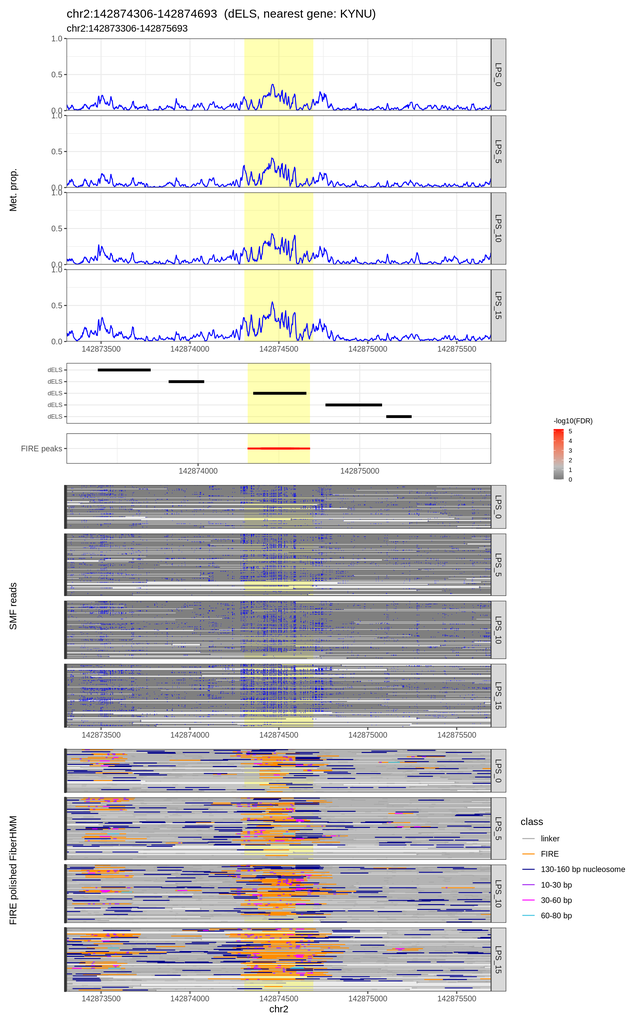

```
## === chr2:55585837-55586002 (dELS, nearest gene: PPP4R3B) ===
## Loading LPS_0 from /project/spott/cshan/fiber-seq/macrophage_project/fire_frequency/region_plots/chr2_55585837_55586002/LPS_0/parsed
## Loading LPS_5 from /project/spott/cshan/fiber-seq/macrophage_project/fire_frequency/region_plots/chr2_55585837_55586002/LPS_5/parsed
## Loading LPS_10 from /project/spott/cshan/fiber-seq/macrophage_project/fire_frequency/region_plots/chr2_55585837_55586002/LPS_10/parsed
## Loading LPS_15 from /project/spott/cshan/fiber-seq/macrophage_project/fire_frequency/region_plots/chr2_55585837_55586002/LPS_15/parsed
## 351 reads in the region across 4 samples
## 2605 TF footprints, 448 of them inside a FIRE element
## 2219 nucleosome calls in 130-160 bp
## 351 reads in region result; 351 grouped; 0 dropped.
##
##          LPS_0 LPS_10 LPS_15 LPS_5
##   LPS_0     89      0      0     0
##   LPS_5      0      0      0    70
##   LPS_10     0    107      0     0
##   LPS_15     0      0     85     0
```

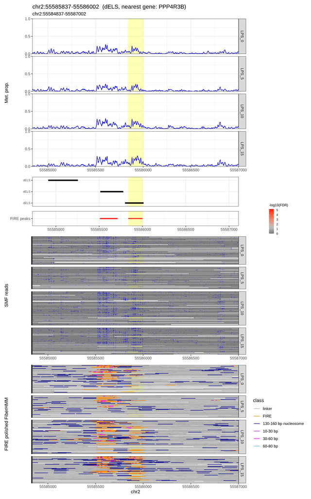

```
## === chr1:55215692-55215938 (pELS, nearest gene: USP24) ===
## Loading LPS_0 from /project/spott/cshan/fiber-seq/macrophage_project/fire_frequency/region_plots/chr1_55215692_55215938/LPS_0/parsed
## Loading LPS_5 from /project/spott/cshan/fiber-seq/macrophage_project/fire_frequency/region_plots/chr1_55215692_55215938/LPS_5/parsed
## Loading LPS_10 from /project/spott/cshan/fiber-seq/macrophage_project/fire_frequency/region_plots/chr1_55215692_55215938/LPS_10/parsed
## Loading LPS_15 from /project/spott/cshan/fiber-seq/macrophage_project/fire_frequency/region_plots/chr1_55215692_55215938/LPS_15/parsed
## 263 reads in the region across 4 samples
## 3150 TF footprints, 798 of them inside a FIRE element
## 2229 nucleosome calls in 130-160 bp
## 263 reads in region result; 263 grouped; 0 dropped.
##
##          LPS_0 LPS_10 LPS_15 LPS_5
##   LPS_0     55      0      0     0
##   LPS_5      0      0      0    62
##   LPS_10     0     66      0     0
##   LPS_15     0      0     80     0
```

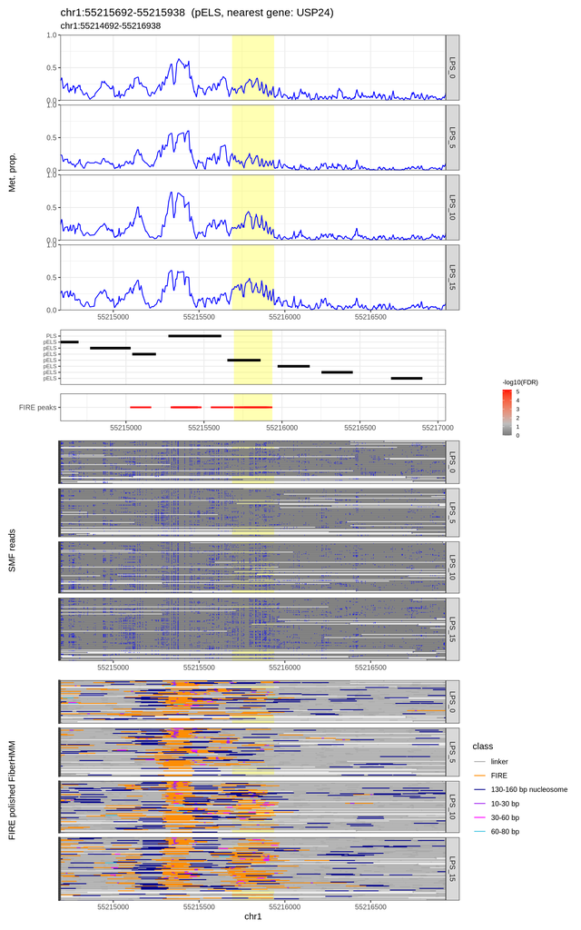

```
## === chr9:123002826-123003054 (dELS, nearest gene: RABGAP1) ===
## Loading LPS_0 from /project/spott/cshan/fiber-seq/macrophage_project/fire_frequency/region_plots/chr9_123002826_123003054/LPS_0/parsed
## Loading LPS_5 from /project/spott/cshan/fiber-seq/macrophage_project/fire_frequency/region_plots/chr9_123002826_123003054/LPS_5/parsed
## Loading LPS_10 from /project/spott/cshan/fiber-seq/macrophage_project/fire_frequency/region_plots/chr9_123002826_123003054/LPS_10/parsed
## Loading LPS_15 from /project/spott/cshan/fiber-seq/macrophage_project/fire_frequency/region_plots/chr9_123002826_123003054/LPS_15/parsed
## 315 reads in the region across 4 samples
## 2600 TF footprints, 437 of them inside a FIRE element
## 2051 nucleosome calls in 130-160 bp
## 315 reads in region result; 315 grouped; 0 dropped.
##
##          LPS_0 LPS_10 LPS_15 LPS_5
##   LPS_0     75      0      0     0
##   LPS_5      0      0      0    92
##   LPS_10     0     78      0     0
##   LPS_15     0      0     70     0
```

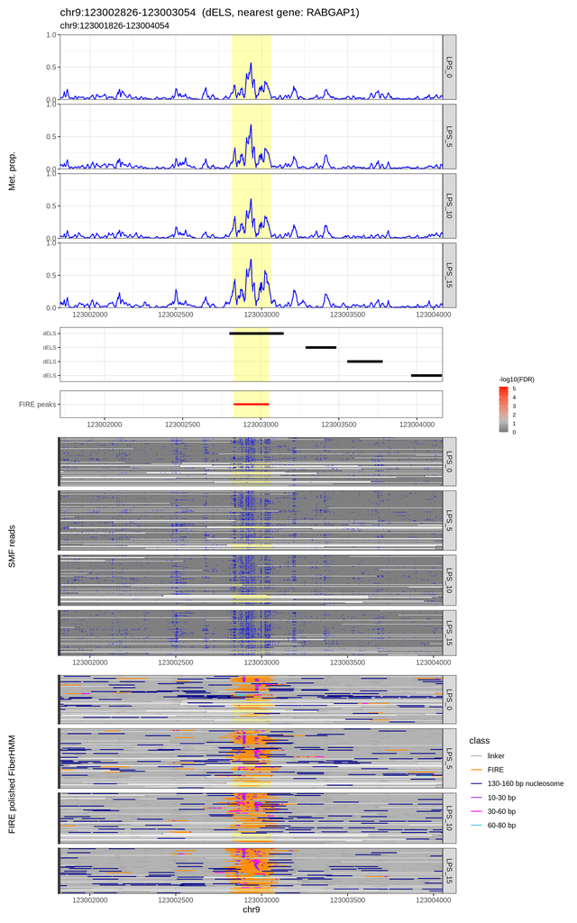

```
## === chr2:201117004-201117208 (pELS, nearest gene: CFLAR) ===
## Loading LPS_0 from /project/spott/cshan/fiber-seq/macrophage_project/fire_frequency/region_plots/chr2_201117004_201117208/LPS_0/parsed
## Loading LPS_5 from /project/spott/cshan/fiber-seq/macrophage_project/fire_frequency/region_plots/chr2_201117004_201117208/LPS_5/parsed
## Loading LPS_10 from /project/spott/cshan/fiber-seq/macrophage_project/fire_frequency/region_plots/chr2_201117004_201117208/LPS_10/parsed
## Loading LPS_15 from /project/spott/cshan/fiber-seq/macrophage_project/fire_frequency/region_plots/chr2_201117004_201117208/LPS_15/parsed
## 247 reads in the region across 4 samples
## 3487 TF footprints, 1262 of them inside a FIRE element
## 1862 nucleosome calls in 130-160 bp
## 247 reads in region result; 247 grouped; 0 dropped.
##
##          LPS_0 LPS_10 LPS_15 LPS_5
##   LPS_0     49      0      0     0
##   LPS_5      0      0      0    62
##   LPS_10     0     74      0     0
##   LPS_15     0      0     62     0
```

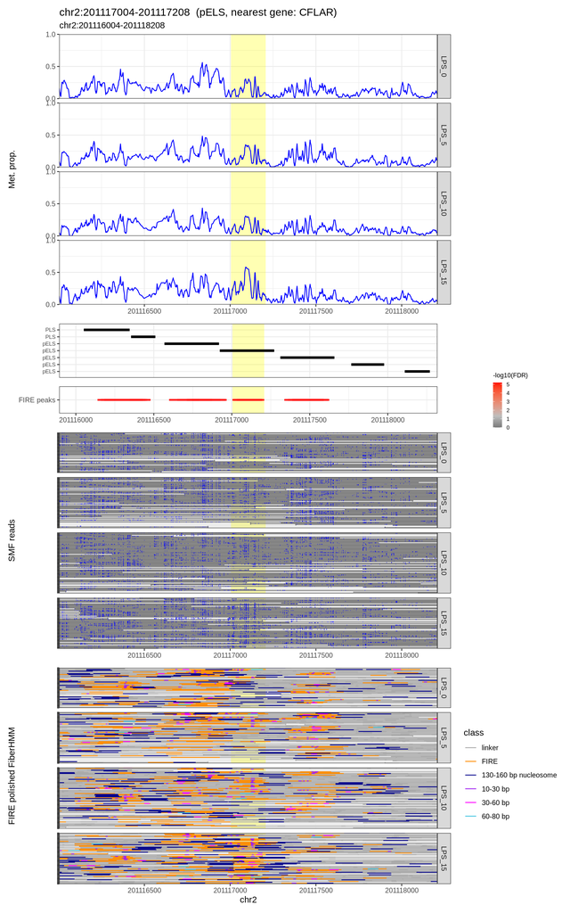

```
## === chr6:43224386-43224664 (pELS, nearest gene: CUL9) ===
## Loading LPS_0 from /project/spott/cshan/fiber-seq/macrophage_project/fire_frequency/region_plots/chr6_43224386_43224664/LPS_0/parsed
## Loading LPS_5 from /project/spott/cshan/fiber-seq/macrophage_project/fire_frequency/region_plots/chr6_43224386_43224664/LPS_5/parsed
## Loading LPS_10 from /project/spott/cshan/fiber-seq/macrophage_project/fire_frequency/region_plots/chr6_43224386_43224664/LPS_10/parsed
## Loading LPS_15 from /project/spott/cshan/fiber-seq/macrophage_project/fire_frequency/region_plots/chr6_43224386_43224664/LPS_15/parsed
## 334 reads in the region across 4 samples
## 3260 TF footprints, 603 of them inside a FIRE element
## 3151 nucleosome calls in 130-160 bp
## 334 reads in region result; 334 grouped; 0 dropped.
##
##          LPS_0 LPS_10 LPS_15 LPS_5
##   LPS_0     91      0      0     0
##   LPS_5      0      0      0    78
##   LPS_10     0     79      0     0
##   LPS_15     0      0     86     0
```

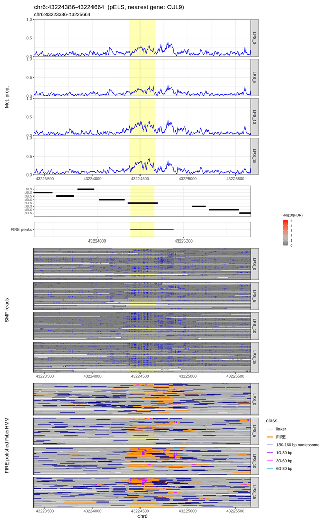

```
## === chr3:101827658-101828081 (PLS, nearest gene: NFKBIZ) ===
## Loading LPS_0 from /project/spott/cshan/fiber-seq/macrophage_project/fire_frequency/region_plots/chr3_101827658_101828081/LPS_0/parsed
## Loading LPS_5 from /project/spott/cshan/fiber-seq/macrophage_project/fire_frequency/region_plots/chr3_101827658_101828081/LPS_5/parsed
## Loading LPS_10 from /project/spott/cshan/fiber-seq/macrophage_project/fire_frequency/region_plots/chr3_101827658_101828081/LPS_10/parsed
## Loading LPS_15 from /project/spott/cshan/fiber-seq/macrophage_project/fire_frequency/region_plots/chr3_101827658_101828081/LPS_15/parsed
## 319 reads in the region across 4 samples
## 3742 TF footprints, 753 of them inside a FIRE element
## 2532 nucleosome calls in 130-160 bp
## 319 reads in region result; 319 grouped; 0 dropped.
##
##          LPS_0 LPS_10 LPS_15 LPS_5
##   LPS_0     67      0      0     0
##   LPS_5      0      0      0    77
##   LPS_10     0    102      0     0
##   LPS_15     0      0     73     0
```

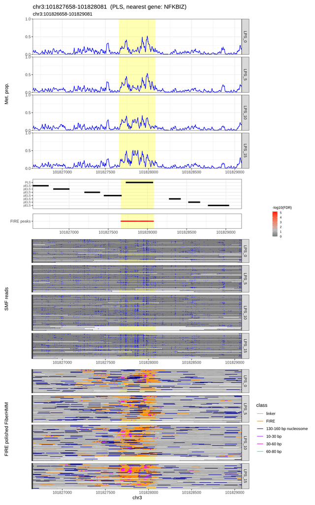

```
## === chr15:64883161-64883451 (pELS, nearest gene: ENSG00000249240) ===
## Loading LPS_0 from /project/spott/cshan/fiber-seq/macrophage_project/fire_frequency/region_plots/chr15_64883161_64883451/LPS_0/parsed
## Loading LPS_5 from /project/spott/cshan/fiber-seq/macrophage_project/fire_frequency/region_plots/chr15_64883161_64883451/LPS_5/parsed
## Loading LPS_10 from /project/spott/cshan/fiber-seq/macrophage_project/fire_frequency/region_plots/chr15_64883161_64883451/LPS_10/parsed
## Loading LPS_15 from /project/spott/cshan/fiber-seq/macrophage_project/fire_frequency/region_plots/chr15_64883161_64883451/LPS_15/parsed
## 239 reads in the region across 4 samples
## 3417 TF footprints, 1599 of them inside a FIRE element
## 1790 nucleosome calls in 130-160 bp
## 239 reads in region result; 239 grouped; 0 dropped.
##
##          LPS_0 LPS_10 LPS_15 LPS_5
##   LPS_0     57      0      0     0
##   LPS_5      0      0      0    72
##   LPS_10     0     53      0     0
##   LPS_15     0      0     57     0
```

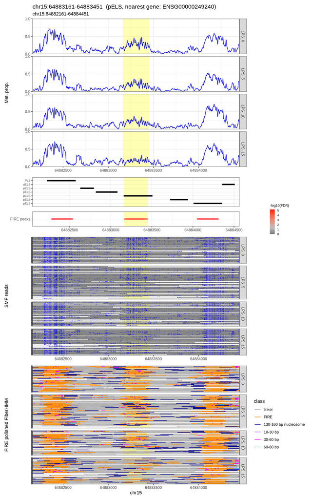

```r
for (i in seq_len(nrow(top10))) {
  row <- top10[i, ]
  cat("=== ", row$region_id, " (", row$ccre_class, ", nearest gene: ",
      row$nearest_gene, ") ===\n", sep = "")

  res <- load_region_results(
    region       = data.frame(chr = row$chrom, start = row$window_start,
                              end = row$window_end),
    sample_names = sample_names,
    result_dirs  = file.path(extract_root, row$outname, sample_names, "parsed"),
    fiberHMM_feature      = "tf",
    min_fiberHMM_fp_score = 50,
    fiberHMM_size_breaks  = c(10, 30, 60, 80))

  # facet the read-level panels and the pileup by timepoint
  res <- add_read_groups(res,
                         labels = setNames(as.character(res$rids_df$sample_name),
                                           as.character(res$rids_df$RID)),
                         group_col = "timepoint",
                         group_levels = sample_names)

  # cCREs in the window, one row per cCRE labelled with its class; the tested region
  # itself is the yellow band behind every panel
  peaks_df <- ccre %>%
    filter(chr == row$chrom, end > row$window_start, start < row$window_end) %>%
    arrange(ccre_class, start) %>%
    transmute(chr, start, end, group = ccre_class)

  p <- plot_region_panels(res,
                          plot_name = paste0(row$region_id, "  (", row$ccre_class,
                                             ", nearest gene: ", row$nearest_gene, ")"),
                          peaks_df = peaks_df,
                          highlight = c(row$start, row$end),
                          fiberHMM_cols = c("purple", "magenta", "#41c4e1"),
                          heights = c(pileup = 10, peaks = 2, fire_peaks = 1,
                                      reads = 8, fire_fiberHMM = 8))
  print(p$combined)
}
```

# Top 10 cCRE-supported regions: LPS time-course example figures

The same 10 regions as the read-level plots above (`top10`: cCRE-supported, nearest gene protein coding, ranked by best pairwise Fisher p). Every panel uses the same window, the tested FIRE region +/- `pad` bp (`window_start`-`window_end`), and marks the tested region itself.

Molecules are the full-span reads of the Leiden + Manhattan workflow (`assemble_region_m6a(full_span = TRUE)`: reads whose longest alignment physically spans the complete analysis window, including reads with zero m6A calls in the window), so panels A-D all describe the same reads. Each timepoint is one merged sample (`LPS_0` … `LPS_15`, biological replicates already pooled), as in the rest of this notebook.

- **A** aggregate m6A per timepoint: the pileup of the read-level plots above (`pileup_reads()`: fraction of reads with an m6A call at each A, +/- 5 bp sliding mean), with ENCODE cCREs in the window.
- **B** every full-span molecule, by timepoint, not clustered (rows ordered by alignment start). Footprint encoding of the read-level plots above: FIRE / linker segmentation from `fire.bed`, FiberHMM 130-160 bp nucleosomes, and FIRE-polished FiberHMM TF footprints.
- **C** Leiden + Manhattan clustering of the molecules pooled over 0-15 min, with the settings of `marcophage_leiden_manhattan.Rmd` (site-level 0/1 m6A matrix, no windowing, k = 10, resolution 1). Timepoint is metadata only and no haplotype information is used. C1 = m6A heatmap, C2 = per-cluster m6A pileup and every molecule’s footprints, by cluster.
- **D** cluster composition per timepoint, P(cluster | time).

Only PDFs are written, one folder per region under `top10_example_plots/`.

```r
suppressPackageStartupMessages({
  library(Matrix)
  library(igraph)
  library(ComplexHeatmap)
  library(cowplot)
  library(patchwork)
})
source("/project/spott/cshan/fiber-seq/code/parsing_functions/parsing_footprints_functions.r")
source("/project/spott/cshan/fiber-seq/code/clustering_methods/Leiden_Manhattan/leiden_manhattan_functions.r")
source("/project/spott/cshan/fiber-seq/code/parsing_functions/plotting_functions.r", local = TRUE)
source("/project/spott/cshan/fiber-seq/code/clustering_methods/Leiden_Manhattan/leiden_manhattan_plots.r")
ht_opt$message <- FALSE

example_dir   <- file.path(input_dir, "top10_example_plots")
ft_result_dir <- "/project/spott/cshan/fiber-seq/macrophage_project/FiberHMM/extract/ft_result_dir"

sample_table <- tibble::tribble(
  ~sample_name, ~condition, ~timepoint,
  "LPS_0",      "LPS",       0L,
  "LPS_5",      "LPS",       5L,
  "LPS_10",     "LPS",       10L,
  "LPS_15",     "LPS",       15L
)

# Leiden + Manhattan settings of marcophage_leiden_manhattan.Rmd
window_size       <- 0L
k_neighbors       <- 10
leiden_resolution <- 1
leiden_seed       <- 1
kernel_sigma      <- NULL

time_levels <- c("0 min", "5 min", "10 min", "15 min")
time_labels <- setNames(time_levels, sample_names)
time_cols   <- timepoint_palette(time_levels)

# footprint colours of plot_region_panels() in the read-level plots above
fp_cols <- c("linker (non-FIRE MSP)"  = "darkgray",
             "FIRE element"           = "#FF8C00",
             "nucleosome 130-160 bp"  = "darkblue",
             "TF footprint 10-30 bp"  = "purple",
             "TF footprint 30-60 bp"  = "magenta",
             "TF footprint 60-80 bp"  = "#41c4e1")

# ENCODE SCREEN cCRE colours
ccre_cols <- c(PLS = "#FF0000", pELS = "#FFA700", dELS = "#FFCD00",
               "CA-H3K4me3" = "#FFAAAA", "CA-CTCF" = "#00B0F0", "CA-TF" = "#BE28E5",
               CA = "#06DA93", TF = "#D876EC", "tested FIRE region" = "black")
```

```r
top10_examples_regions <- top10 %>%
  mutate(example_id = sprintf("rank%02d_%s", rank, outname)) %>%
  select(rank, example_id, outname, region_id, chrom, start, end, window_start, window_end,
         best_comparison, n_signif_comparisons, min_p, delta_freq_best,
         ccre_id, ccre_class, ccre_frac, nearest_gene, gene_distance)

# FIRE frequency of the tested region at each timepoint (fire_frequency_long)
top10_fire_freq <- fire_freq %>%
  filter(region_id %in% top10_examples_regions$region_id) %>%
  mutate(time = factor(time_labels[timepoint], levels = time_levels)) %>%
  select(region_id, time, n_reads, n_fire, freq)

top10_examples_regions %>%
  mutate(min_p = signif(min_p, 3), delta_freq_best = round(delta_freq_best, 3),
         ccre_frac = round(ccre_frac, 2)) %>%
  select(-region_id)
```

```
## # A tibble: 10 × 17
##     rank example_id          outname chrom  start    end window_start window_end
##    <int> <chr>               <chr>   <chr>  <dbl>  <dbl>        <int>      <int>
##  1     1 rank01_chr11_12858… chr11_… chr11 1.29e8 1.29e8    128581973  128584191
##  2     2 rank02_chr4_112284… chr4_1… chr4  1.12e8 1.12e8    112283963  112286236
##  3     3 rank03_chr2_142874… chr2_1… chr2  1.43e8 1.43e8    142873306  142875693
##  4     4 rank04_chr2_555858… chr2_5… chr2  5.56e7 5.56e7     55584837   55587002
##  5     5 rank05_chr1_552156… chr1_5… chr1  5.52e7 5.52e7     55214692   55216938
##  6     6 rank06_chr9_123002… chr9_1… chr9  1.23e8 1.23e8    123001826  123004054
##  7     7 rank07_chr2_201117… chr2_2… chr2  2.01e8 2.01e8    201116004  201118208
##  8     8 rank08_chr6_432243… chr6_4… chr6  4.32e7 4.32e7     43223386   43225664
##  9     9 rank09_chr3_101827… chr3_1… chr3  1.02e8 1.02e8    101826658  101829081
## 10    10 rank10_chr15_64883… chr15_… chr15 6.49e7 6.49e7     64882161   64884451
## # ℹ 9 more variables: best_comparison <fct>, n_signif_comparisons <int>,
## #   min_p <dbl>, delta_freq_best <dbl>, ccre_id <chr>, ccre_class <chr>,
## #   ccre_frac <dbl>, nearest_gene <chr>, gene_distance <int>
```